# Практика 15 · Регуляризація

> 📖 **Теорія:** відкрий `lecture.html` у цій же теці. 📝 **Домашнє завдання:** `homework.html`. 🧠 **Тест:** `quiz.html`.

Лекція показала третій спосіб приборкати перенавчання: не спрощувати модель і не добувати даних, а додати до функції втрат штраф за величину ваг. Тут ми зробимо це руками й побачимо в числах усе, про що йшлося.

**Що зробимо:**

1. Відтворимо перенавчений многочлен і **надрукуємо його ваги** — ті самі мільйони
2. Напишемо гребеневу регресію самі й переконаємось, що вона збігається з `Ridge`
3. Подивимось у таблиці, як штраф стискає ваги — і що жодна з них не стає нулем
4. Замінимо квадрат на модуль і порахуємо, скільки ваг `Lasso` обнулив **точно**
5. Підберемо силу штрафу крос-валідацією через `RidgeCV` і `LassoCV`
6. Перевіримо, що без зрівнювання масштабу відповідь залежить від одиниць виміру

> Числа тут не збігатимуться з лекцією до гривні: там дані породжував генератор браузера, тут — NumPy. Явище й усі висновки ті самі.

## 0. Ті самі оголошення про телефони

Дошка оголошень про вживані телефони рідкісної марки. Ціна залежить від року випуску: телефон дешевшає з віком, але не по прямій, плюс невеликий горб на 2019-му — тодішня серія вийшла вдалою. До закономірності додається **шум**: подряпина на корпусі, продавець поспішає, продавець поставив із запасом.

У житті істину ніхто не знає. Тут знаємо ми, бо самі її задали, — і тому зможемо показати пальцем, де модель вивчила закономірність, а де шум.

```python
import numpy as np
import pandas as pd
import matplotlib.pyplot as plt
from numpy.polynomial import legendre

ПЕРШИЙ_РІК = 2010          # найстаріший телефон на дошці
ОСТАННІЙ_РІК = 2025        # найновіший
РОЗКИД_ЦІН = 750           # шум: стандартне відхилення в гривнях


def грн(число):
    """Число з пробілами між тисячами: 1 615 407 читається краще за 1615407."""
    return f"{число:,.0f}".replace(",", " ")


def справжня_ціна(рік):
    """Закономірність, якої модель не знає: здешевлення з віком плюс горб на 2019."""
    здешевлення = 1900 + 18500 * 0.80 ** (ОСТАННІЙ_РІК - рік)
    вдала_серія = 1500 * np.exp(-((рік - 2019) / 1.3) ** 2)
    return здешевлення + вдала_серія


def згенерувати_оголошення(rng, скільки):
    """Оголошення = справжня ціна свого року плюс випадкове відхилення."""
    роки = np.sort(rng.uniform(ПЕРШИЙ_РІК, ОСТАННІЙ_РІК, скільки))
    ціни = справжня_ціна(роки) + rng.normal(0, РОЗКИД_ЦІН, скільки)
    return роки, ціни


rng = np.random.default_rng(42)
роки_навчання, ціни_навчання = згенерувати_оголошення(rng, 16)
роки_тесту, ціни_тесту = згенерувати_оголошення(rng, 300)

print(f"навчальних оголошень: {len(роки_навчання)}")
print(f"тестових оголошень:   {len(роки_тесту)}")
print("\nперші чотири навчальні оголошення:")
for рік, ціна in zip(роки_навчання[:4], ціни_навчання[:4]):
    print(f"  {рік:.2f} → {грн(ціна):>7} ₴")
```

```
навчальних оголошень: 16
тестових оголошень:   300

перші чотири навчальні оголошення:
  2011.41 →   3 069 ₴
  2011.92 →   2 180 ₴
  2013.41 →   3 952 ₴
  2015.56 →   4 116 ₴
```

## 1. Одна ознака перетворюється на пʼятнадцять

Модель у нас та сама лінійна регресія, просто ознак у неї більше однієї: замість самого лише року ми даємо їй **пʼятнадцять стандартних форм кривої**. Форма 1 — похила пряма, форма 2 — одна дуга, форма 3 — дві дуги, і далі чим більший номер, тим більше вигинів. Модель підбирає, скільки гривень додає кожна форма, — це і є її **ваги**.

Тут є технічна пастка. Якщо будувати форми як сирі степені року — `рік`, `рік²`, …, `рік¹⁵` — то при роках близько 2020 значення `рік¹⁵` має порядок 10⁴⁹, стовпці матриці стають майже однаковими, і замість перенавчання ми отримаємо **чисельне сміття**. Рятує це дві дії разом: стиснути роки у відрізок `[-1, 1]` і взяти не сирі степені, а многочлени Лежандра.

Нульову форму — горизонтальну пряму — ми з матриці ознак **прибираємо**. Її роль грає вільний член моделі, а вільний член штрафувати не можна: інакше модель каратимуть просто за те, що телефони коштують десять тисяч, а не нуль.

```python
СТЕПІНЬ = 15


def у_відрізок(роки):
    """Стискаємо роки в [-1, 1]: без цього високі степені розвалюються чисельно."""
    return 2 * (роки - ПЕРШИЙ_РІК) / (ОСТАННІЙ_РІК - ПЕРШИЙ_РІК) - 1


def ознаки(роки):
    """Пʼятнадцять форм кривої для кожного року. Нульову (сталу) відкидаємо."""
    return legendre.legvander(у_відрізок(роки), СТЕПІНЬ)[:, 1:]


X_навчання = ознаки(роки_навчання)
X_тесту = ознаки(роки_тесту)

print("матриця ознак навчання:", X_навчання.shape, "— 16 оголошень × 15 форм")
print("\nрозмах кожної форми (стандартне відхилення):")
print(np.round(X_навчання.std(axis=0), 3))
print("\nформи майже одного розмаху — це знадобиться нам у розділі 7")
```

```
матриця ознак навчання: (16, 15) — 16 оголошень × 15 форм

розмах кожної форми (стандартне відхилення):
[0.549 0.403 0.348 0.318 0.274 0.253 0.224 0.188 0.176 0.211 0.201 0.195
 0.215 0.158 0.149]

форми майже одного розмаху — це знадобиться нам у розділі 7
```

## 2. Перенавчена модель зсередини

Навчимо модель **без жодного штрафу** й подивимось не на криву, а на числа, з яких вона складена. Пʼятнадцять ваг плюс вільний член — рівно стільки ж вільних чисел, скільки в нас оголошень, тож крива пройде точно через кожну точку.

Дивись на порядок величин.

```python
from sklearn.linear_model import LinearRegression


def rmse(справжні_ціни, прогнози):
    """Середня квадратична помилка в гривнях."""
    return float(np.sqrt(np.mean((справжні_ціни - прогнози) ** 2)))


без_штрафу = LinearRegression().fit(X_навчання, ціни_навчання)

print("ваги моделі без штрафу:")
for номер, вага in enumerate(без_штрафу.coef_, start=1):
    print(f"  форма {номер:>2}: {грн(вага):>18} ₴")

print()
print(f"найбільша вага:      {грн(np.abs(без_штрафу.coef_).max())} ₴")
print(f"сума модулів ваг:    {грн(np.abs(без_штрафу.coef_).sum())} ₴")
print(f"помилка на навчанні: {грн(rmse(ціни_навчання, без_штрафу.predict(X_навчання)))} ₴")
print(f"помилка на тесті:    {грн(rmse(ціни_тесту, без_штрафу.predict(X_тесту)))} ₴")
```

```
ваги моделі без штрафу:
  форма  1:       -815 392 351 ₴
  форма  2:      1 259 912 020 ₴
  форма  3:     -1 575 066 777 ₴
  форма  4:      1 735 873 393 ₴
  форма  5:     -1 747 504 061 ₴
  форма  6:      1 625 020 889 ₴
  форма  7:     -1 407 702 978 ₴
  форма  8:      1 128 366 008 ₴
  форма  9:       -835 024 028 ₴
  форма 10:        557 842 723 ₴
  форма 11:       -333 230 013 ₴
  форма 12:        169 679 488 ₴
  форма 13:        -72 351 840 ₴
  форма 14:         22 435 160 ₴
  форма 15:         -4 770 957 ₴

найбільша вага:      1 747 504 061 ₴
сума модулів ваг:    13 290 172 687 ₴
помилка на навчанні: 0 ₴
помилка на тесті:    1 065 790 375 ₴
```

Ваги — мільярди гривень, а прогнозує ця модель телефони по десять тисяч. Сусідні доданки протилежних знаків майже повністю гасять одне одного, і відповідь моделі — це маленький залишок від різниці величезних чисел. Такий залишок нічим не контрольований: саме тому між точками крива пірнає в мінус мільйони.

Помилка на навчанні при цьому **нульова**. Якби ти дивився лише на неї, ти б доповів, що задачу розвʼязано ідеально.

## 3. Штраф: пишемо гребеневу регресію самі

Гребенева регресія (Ridge) мінімізує не просто суму квадратів промахів, а суму промахів **плюс** `α` помножене на суму квадратів ваг. Розвʼязок знаходиться так само, як звичайний МНК, тільки до діагоналі матриці додається `α`:

```
(XᵀX + αI) · w = Xᵀy
```

Щоб вільний член лишився без штрафу, ознаки й відповідь спершу центрують — віднімають середні. Напишемо це в чотири рядки й порівняємо з бібліотечним `Ridge`.

```python
from sklearn.linear_model import Ridge


def наш_гребінь(X, y, альфа):
    """Ridge вручну. Центрування потрібне, щоб вільний член лишився без штрафу."""
    середні_ознаки = X.mean(axis=0)
    середня_ціна = y.mean()
    Xц = X - середні_ознаки
    yц = y - середня_ціна
    ваги = np.linalg.solve(Xц.T @ Xц + альфа * np.eye(X.shape[1]), Xц.T @ yц)
    вільний_член = середня_ціна - середні_ознаки @ ваги
    return ваги, вільний_член


наші_ваги, наш_вільний = наш_гребінь(X_навчання, ціни_навчання, альфа=1.0)
бібліотечна = Ridge(alpha=1.0).fit(X_навчання, ціни_навчання)

print(f"найбільше розходження ваг:  {np.abs(наші_ваги - бібліотечна.coef_).max():.2e} ₴")
print(f"розходження вільного члена: {abs(наш_вільний - бібліотечна.intercept_):.2e} ₴")

assert np.allclose(наші_ваги, бібліотечна.coef_), "розрахунок розійшовся!"
assert np.allclose(наш_вільний, бібліотечна.intercept_), "вільний член розійшовся!"
print("\n✅ збігається — усередині Ridge той самий доданок αI на діагоналі")
```

```
найбільше розходження ваг:  9.09e-13 ₴
розходження вільного члена: 9.09e-13 ₴

✅ збігається — усередині Ridge той самий доданок αI на діагоналі
```

## 4. Що штраф робить із вагами

Тепер прогонимо `α` від майже нуля до дуже великого й подивимось одразу на чотири речі: наскільки стиснулась найбільша вага, скільки ваг стало **точно** нулем, і як рухаються обидві помилки.

```python
рядки = []
for альфа in [0.001, 0.01, 0.1, 1, 10, 100, 1000]:
    модель = Ridge(alpha=альфа).fit(X_навчання, ціни_навчання)
    рядки.append({
        "альфа": альфа,
        "найбільша вага": round(np.abs(модель.coef_).max()),
        "сума модулів": round(np.abs(модель.coef_).sum()),
        # саме точний нуль, а не «менше за 1e-6»: у цьому вся різниця L1 і L2
        "точних нулів": int((модель.coef_ == 0).sum()),
        "помилка навчання": round(rmse(ціни_навчання, модель.predict(X_навчання))),
        "помилка тесту": round(rmse(ціни_тесту, модель.predict(X_тесту))),
    })

таблиця_ridge = pd.DataFrame(рядки).set_index("альфа")
print(таблиця_ridge.to_string())
```

```
          найбільша вага  сума модулів  точних нулів  помилка навчання  помилка тесту
альфа
0.001               7841         46257             0               198           2894
0.010               7530         26444             0               242           1416
0.100               7346         20253             0               291           1081
1.000               6264         15235             0               897           1241
10.000              2623          6250             0              3264           3205
100.000              388           916             0              4740           4554
1000.000              41            96             0              4970           4766
```

## 5. Ласо: модуль замість квадрата

Замінимо в штрафі `w²` на `|w|`. Похідна від модуля дорівнює ±1 **завжди**, скільки б вага не важила, — тиск не слабшає біля нуля й доводить вагу рівно до нього.

Одна технічна деталь: `scikit-learn` мінімізує для `Lasso` вираз `(1/2n)·Σ(y−ŷ)² + α·Σ|w|`, а для `Ridge` — `Σ(y−ŷ)² + α·Σw²`. Через цей множник однакове `alpha` означає для них зовсім різну силу штрафу, тому й сітки різні.

```python
from sklearn.linear_model import Lasso

рядки = []
for альфа in [0.1, 1, 10, 30, 100, 300, 1000]:
    # ознаки-многочлени сильно корельовані, тож покоординатному спуску
    # всередині Lasso потрібно більше проходів, ніж за замовчуванням
    модель = Lasso(alpha=альфа, max_iter=2_000_000, tol=1e-6).fit(X_навчання, ціни_навчання)
    рядки.append({
        "альфа": альфа,
        "найбільша вага": round(np.abs(модель.coef_).max()),
        "точних нулів": int((модель.coef_ == 0).sum()),
        "помилка навчання": round(rmse(ціни_навчання, модель.predict(X_навчання))),
        "помилка тесту": round(rmse(ціни_тесту, модель.predict(X_тесту))),
    })

таблиця_lasso = pd.DataFrame(рядки).set_index("альфа")
print(таблиця_lasso.to_string())
```

```
        найбільша вага  точних нулів  помилка навчання  помилка тесту
альфа
0.1               9269             3               190           3676
1.0               8396             5               246           1572
10.0              7757             6               317            884
30.0              7821            10               467            844
100.0             7546            12               679            849
300.0             6986            13              1097            991
1000.0            5185            14              2548           2146
```

Колонка «точних нулів» тепер росте. Це не «майже нуль» і не «дуже мало» — це нуль, який дорівнює нулю, тобто ознака з моделі зникла зовсім. Подивимось поіменно, які форми ласо лишило собі.

```python
ласо = Lasso(alpha=30, max_iter=2_000_000, tol=1e-6).fit(X_навчання, ціни_навчання)

вижили = [номер for номер, вага in enumerate(ласо.coef_, start=1) if вага != 0]
викинуті = [номер for номер, вага in enumerate(ласо.coef_, start=1) if вага == 0]

print("форми, які ласо лишило: ", вижили)
print("форми, які ласо викинуло:", викинуті)
print(f"\nмодель тепер спирається на {len(вижили)} ознак замість {СТЕПІНЬ},")
print("і вирішила це вона сама — ми лише виставили ціну за складність")
```

```
форми, які ласо лишило:  [1, 2, 3, 6, 7]
форми, які ласо викинуло: [4, 5, 8, 9, 10, 11, 12, 13, 14, 15]

модель тепер спирається на 5 ознак замість 15,
і вирішила це вона сама — ми лише виставили ціну за складність
```

## 6. Скільки штрафу насипати: крос-валідація

Досі ми підглядали в тестову помилку, щоб знайти найкраще `α`. У справжній задачі так робити не можна: дані, за якими ти щось **обираєш**, більше не годяться, щоб **оцінювати** обране.

Правильний інструмент — крос-валідація на навчальних оголошеннях. Оголошень у нас шістнадцять, тож беремо вісім частин по два: у кожному розбитті модель бачить чотирнадцять прикладів, а міряється на двох, яких не бачила. Тестового конверта не торкаємось узагалі.

```python
from sklearn.linear_model import RidgeCV, LassoCV

сітка_ridge = np.logspace(-3, 3, 7)     # 0.001, 0.01, … 1000 — крок у порядок
сітка_lasso = np.logspace(-1, 3, 9)     # своя сітка: штраф міряється інакше

гребінь_cv = RidgeCV(alphas=сітка_ridge, cv=8).fit(X_навчання, ціни_навчання)
ласо_cv = LassoCV(alphas=сітка_lasso, cv=8,
                  max_iter=2_000_000, tol=1e-6).fit(X_навчання, ціни_навчання)

print(f"RidgeCV обрала α = {гребінь_cv.alpha_:g}")
print(f"   помилка на тесті: {грн(rmse(ціни_тесту, гребінь_cv.predict(X_тесту)))} ₴")
print(f"LassoCV обрала α = {ласо_cv.alpha_:g}, обнуливши "
      f"{int((ласо_cv.coef_ == 0).sum())} ваг із {СТЕПІНЬ}")
print(f"   помилка на тесті: {грн(rmse(ціни_тесту, ласо_cv.predict(X_тесту)))} ₴")
print()
print(f"а без штрафу було:   {грн(rmse(ціни_тесту, без_штрафу.predict(X_тесту)))} ₴")
```

```
RidgeCV обрала α = 0.1
   помилка на тесті: 1 081 ₴
LassoCV обрала α = 31.6228, обнуливши 10 ваг із 15
   помилка на тесті: 842 ₴

а без штрафу було:   1 065 790 375 ₴
```

Намалюймо всі три криві на одній картинці.

```
крива без штрафу майже не видна на графіку — вона вилітає за його межі:
її мінімум на цьому проміжку — -16 574 858 ₴
```

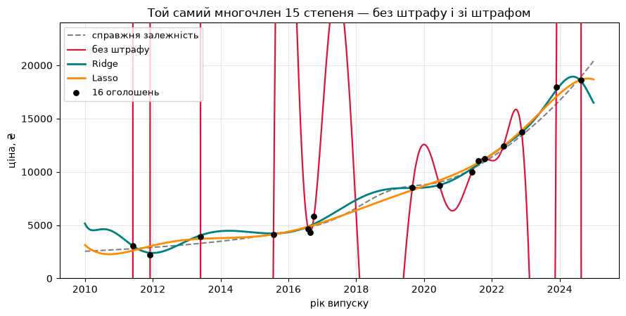

```python
сітка_років = np.linspace(ПЕРШИЙ_РІК, ОСТАННІЙ_РІК, 600)
X_сітки = ознаки(сітка_років)

fig, ax = plt.subplots(figsize=(9, 4.6))
ax.plot(сітка_років, справжня_ціна(сітка_років), "--", color="grey",
        label="справжня залежність")
ax.plot(сітка_років, без_штрафу.predict(X_сітки), color="crimson", lw=1.6,
        label="без штрафу")
ax.plot(сітка_років, гребінь_cv.predict(X_сітки), color="teal", lw=2, label="Ridge")
ax.plot(сітка_років, ласо_cv.predict(X_сітки), color="darkorange", lw=2, label="Lasso")
ax.scatter(роки_навчання, ціни_навчання, color="black", zorder=5, s=28,
           label="16 оголошень")
ax.set_ylim(0, 24000)
ax.set_xlabel("рік випуску")
ax.set_ylabel("ціна, ₴")
ax.set_title("Той самий многочлен 15 степеня — без штрафу і зі штрафом")
ax.legend(fontsize=9)
ax.grid(alpha=0.3)

print("крива без штрафу майже не видна на графіку — вона вилітає за його межі:")
print(f"її мінімум на цьому проміжку — {грн(без_штрафу.predict(X_сітки).min())} ₴")
plt.tight_layout()
plt.show()
```

## 7. Без однакового масштабу штраф стає лотереєю

Штраф `α·Σw²` однаковий для всіх ваг: він не питає, у чому виміряна ознака. Але ваги живуть у різних масштабах саме через одиниці. Запиши ознаку в одиницях, у тисячу разів дрібніших, — вага стане в тисячу разів меншою, а її внесок у штраф впаде в **мільйон** разів, бо в штрафі стоїть квадрат.

Перевіримо це. Візьмемо пʼять різних наборів множників — уявних «одиниць виміру» для наших пʼятнадцяти форм — і кожного разу підберемо `α` крос-валідацією. Двічі: без масштабування й з `StandardScaler` усередині конвеєра.

```python
from sklearn.preprocessing import StandardScaler
from sklearn.pipeline import make_pipeline

еталон = rmse(ціни_тесту, гребінь_cv.predict(X_тесту))   # ознаки як є, розділ 6
rng_одиниці = np.random.default_rng(0)

рядки = []
for варіант in range(1, 6):
    # множники від тисячних до сотень — так виглядають ознаки в різних одиницях
    множники = 10.0 ** rng_одиниці.uniform(-2.5, 2.5, СТЕПІНЬ)
    X_н, X_т = X_навчання * множники, X_тесту * множники

    без_шкали = RidgeCV(alphas=сітка_ridge, cv=8).fit(X_н, ціни_навчання)
    зі_шкалою = make_pipeline(StandardScaler(),
                              RidgeCV(alphas=сітка_ridge, cv=8)).fit(X_н, ціни_навчання)

    рядки.append({
        "варіант одиниць": варіант,
        "без StandardScaler": round(rmse(ціни_тесту, без_шкали.predict(X_т))),
        "зі StandardScaler": round(rmse(ціни_тесту, зі_шкалою.predict(X_т))),
    })

таблиця_масштабу = pd.DataFrame(рядки).set_index("варіант одиниць")
print(таблиця_масштабу.to_string())
print()
print(f"для порівняння, ознаки як є (розділ 6): {round(еталон)} ₴")
print()
print("без StandardScaler:", таблиця_масштабу["без StandardScaler"].nunique(),
      "різних відповідей із 5")
print("зі StandardScaler: ", таблиця_масштабу["зі StandardScaler"].nunique(),
      "різних відповідей із 5")

assert таблиця_масштабу["зі StandardScaler"].nunique() == 1, "масштаб має зникати!"
print("\n✅ StandardScaler робить відповідь незалежною від одиниць виміру")
```

```
                 без StandardScaler  зі StandardScaler
варіант одиниць
1                              2576               2151
2                              5048               2151
3                              1557               2151
4                              1749               2151
5                              2382               2151

для порівняння, ознаки як є (розділ 6): 1081 ₴

без StandardScaler: 5 різних відповідей із 5
зі StandardScaler:  1 різних відповідей із 5

✅ StandardScaler робить відповідь незалежною від одиниць виміру
```

Читай цю таблицю уважно, бо висновок тут тонший, ніж «масштабування покращує якість».

**Ліва колонка — пʼять різних чисел.** Дані ті самі, модель та сама, `α` щоразу підібране крос-валідацією чесно. Змінились лише уявні одиниці виміру — те, що не має жодного стосунку до задачі, — і результат поїхав у рази. Який саме ти отримаєш, залежить від того, у чому колега записав ознаку, і дізнатись, пощастило тобі чи ні, можна лише за тестовою вибіркою, якої в реальній задачі немає.

**Права колонка — одне число пʼять разів.** `StandardScaler` віднімає середнє й ділить на розкид, тому будь-які множники зникають ще до навчання. Відповідь перестала залежати від одиниць — вона тепер визначається даними, а не випадковим рішенням.

## 🎯 Завдання

### 🟢 Рівень 1

Побудуй графік «сила штрафу → найбільша вага моделі» для `Ridge` з `alpha` від `1e-3` до `1e3` (не менше двадцяти точок, вісь `alpha` логарифмічна). Поруч, другою лінією, — «сила штрафу → помилка на тесті».

**Зроблено, якщо:** на графіку видно, що найбільша вага спадає монотонно, а помилка на тесті має мінімум, і ти назвав `alpha`, при якому цей мінімум досягається.

### 🟡 Рівень 2

Додай до пʼятнадцяти форм ще **десять ознак-сміття** — стовпців випадкових чисел, ніяк не повʼязаних із ціною. Підбери `alpha` крос-валідацією для `RidgeCV` і для `LassoCV` і порахуй, скільки ознак-сміття обнулила кожна модель.

**Зроблено, якщо:** `Lasso` обнулив принаймні половину сміття, `Ridge` — жодної ознаки, і ти пояснив двома реченнями, звідки береться ця різниця.

### 🔴 Рівень 3

Реалізуй **ласо** з нуля покоординатним спуском: по черзі перебирай ваги й для кожної став `w = знак(ρ)·max(|ρ| − поріг, 0) / нормаΔ`, де `ρ` — скалярний добуток цієї ознаки із залишком, порахованим без неї. Порівняй результат із `sklearn.linear_model.Lasso` через `assert np.allclose(...)`.

**Зроблено, якщо:** твої ваги збігаються з бібліотечними для трьох різних `alpha`, і ти показав, що саме операція `max(|ρ| − поріг, 0)` дає точні нулі, а її аналог для гребеневої регресії (ділення на `1 + α`) — ні.